# Extended War Report

2026-03-08

# Overview

This is an extended war report for the war **37592** between **Knuckle Sandwich** and **Torn Community Garden**. Data is presented from the side of **Torn Community Garden**. Link to the official war report can be found [HERE](https://www.torn.com/war.php?step=rankreport&rankID=37592).

## Rewards

War outcome for your faction: **Loss**  
Total hits done: **1369**  
War hits: **639**  
Non war hits: **730**  
Total respect earned: **6465.38**  
Members contributed: **45/48**

Rewards for your faction:

| Name | Amount | Price |
| --- | --- | --- |
| Small Arms Cache | 2 | 241.62 M |
| Medium Arms Cache | 2 | 449.02 M |
| Armor Cache | 1 | 326.6 M |

Earnings from caches: **1.02 B**  
Total earnings: **1.02 B**<sup>1</sup>

<sup>1</sup>prices are based on market value or approximate trader prices if market value is unavaliable.

## War Preparation

**NOTE**: Faction Xanax might be different from Prep Xanax due to how personal stats are calculated. In this case, Faction Xanax is more accurate.

Members who **did not stack** energy before war:

|  | Name | Prep_Xanax | Faction_Xanax | Total_Hits |
| --- | --- | --- | --- | --- |
| 1 | Alchemist-Ifrit | 3 |  | 34 |
| 2 | Anthrax132 | 2 | 2 | 56 |
| 3 | BillTheImpaler | 3 | 3 | 19 |
| 4 | Bucknutz | 3 |  | 17 |
| 5 | Captain_Chimkin | 2 |  | 16 |
| 6 | D3adpool | 0 |  | 12 |
| 7 | Darnclip | 1 |  | 5 |
| 8 | EXIGULAE | 0 |  | 32 |
| 9 | FalconCY | 3 | 3 | 24 |
| 10 | FogBorne | 2 | 2 | 25 |

[output cut: 14 more lines]

Members who **overdosed** during war preparations (but could still have stacked):

|  | Name | Prep_Xanax | Faction_Xanax | Total_Hits |
| --- | --- | --- | --- | --- |
| 1 | BarkingPupGirl | 4 |  | 19 |
| 2 | Brenadryl | 6 | 6 | 40 |
| 3 | Ch3wie | 5 |  | 23 |
| 4 | Marika | 4 | 4 | 41 |
| 5 | Nordy14740 | 6 | 7 | 44 |

Members who **most likely stacked** energy before war (or just used lots of xanax):

|  | Name | Prep_Xanax | Faction_Xanax | Total_Hits |
| --- | --- | --- | --- | --- |
| 1 | -CHARIZARD- | 8 |  | 11 |
| 2 | Benedicc | 4 | 4 | 15 |
| 3 | BlackLab | 5 | 3 | 48 |
| 4 | Chapelle | 4 | 2 | 15 |
| 5 | Ezza | 5 |  | 42 |
| 6 | JaBelladonna | 5 | 1 | 39 |
| 7 | MrLuther | 6 | 2 | 0 |
| 8 | NANOO | 4 |  | 70 |
| 9 | Orverus | 5 |  | 15 |
| 10 | RipleyWolf | 4 | 4 | 49 |

[output cut: 9 more lines]

## Fighting summary

### Top 5

Top 5 by overall contribution %

| Name | Contribution |
| --- | --- |
| miel | 5.77 |
| ScatterBean | 5.33 |
| NANOO | 5.11 |
| Zoot | 4.75 |
| Kronosphere | 4.75 |

Top 5 by War hits

| Name | War_Hits |
| --- | --- |
| NANOO | 55 |
| Supreme_ | 27 |
| RoadTo25b | 26 |
| Trang666 | 20 |
| BillTheImpaler | 19 |

Top 5 by Non War hits

| Name | Non_War_Hits |
| --- | --- |
| miel | 63 |
| ScatterBean | 58 |
| Kronosphere | 50 |
| Zoot | 49 |
| Anthrax132 | 41 |

Top 5 by Total hits

| Name | Total_Hits |
| --- | --- |
| miel | 79 |
| ScatterBean | 73 |
| NANOO | 70 |
| Zoot | 65 |
| Kronosphere | 65 |

Top 5 by Assists

| Name | Assists |
| --- | --- |
| Sakura_Yagame | 4 |
| Zoot | 2 |
| Jannerboy | 2 |
| Kronosphere | 2 |
| Marika | 1 |

Chain savers - List of people who saved the chain with less than 60 seconds remaining.

```
## [1] "Friendly chain savers:"
```

| Saver | Chain | Time remaining |
| --- | --- | --- |
| Ezza | 470 | 4 |
| Zoot | 459 | 36 |
| ScatterBean | 377 | 18 |
| miel | 361 | 20 |
| Brenadryl | 286 | 50 |
| Zoot | 285 | 30 |
| Zoot | 284 | 46 |
| Anthrax132 | 283 | 17 |
| Anthrax132 | 282 | 51 |
| Zoot | 281 | 30 |
| Anthrax132 | 280 | 42 |
| Anthrax132 | 277 | 30 |
| Anthrax132 | 221 | 38 |
| Zoot | 217 | 22 |
| Zoot | 216 | 8 |
| Zoot | 215 | 59 |
| Zoot | 214 | 16 |
| Zoot | 213 | 47 |
| Zoot | 212 | 32 |
| Zoot | 210 | 30 |
| Zoot | 208 | 38 |
| BlackLab | 199 | 17 |
| BlackLab | 181 | 40 |
| BlackLab | 176 | 15 |
| Zoot | 156 | 49 |
| BlackLab | 155 | 16 |
| BlackLab | 154 | 35 |
| BlackLab | 147 | 59 |
| BlackLab | 145 | 19 |
| BlackLab | 141 | 24 |
| BlackLab | 139 | 59 |
| BlackLab | 137 | 7 |
| SixtenBlixt | 131 | 29 |
| ScatterBean | 109 | 22 |
| Brenadryl | 83 | 28 |
| Zoot | 81 | 20 |
| BlackLab | 78 | 37 |
| BlackLab | 66 | 48 |
| Brenadryl | 46 | 12 |
| FogBorne | 40 | 40 |
| FogBorne | 38 | 27 |
| Trang666 | 37 | 51 |
| FogBorne | 36 | 16 |
| FogBorne | 35 | 40 |
| FogBorne | 34 | 34 |
| FogBorne | 32 | 39 |
| FogBorne | 31 | 32 |
| FogBorne | 29 | 45 |
| FogBorne | 27 | 57 |

```
## [1] "Enemy chain savers:"
```

| Saver | Chain | Time remaining |
| --- | --- | --- |
| Arcuzz | 415 | 31 |
| Pretty_Pig | 221 | 31 |
| Pretty_Pig | 219 | 55 |
| Pretty_Pig | 201 | 41 |
| Arcuzz | 181 | 28 |
| Arcuzz | 150 | 6 |
| Arcuzz | 145 | 27 |
| GreenPips | 132 | 24 |

### Visual summary

Only including members with non-zero contribution

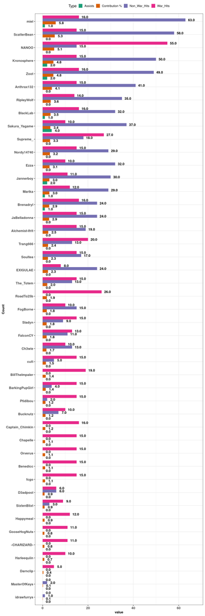

### Respect

Respect earned by each member.<sup>1</sup>  
Total respect earned: **6465.38**  
Total respect lost: **1665.29**  
Net respect change: **4800.09**<sup>2</sup>  
Average respect earned per attack: **4.03**

<sup>1</sup>Chain bonuses are ignored in per-member contributions.  
<sup>2</sup>Respect lost will be 0 if using non-faction API key.

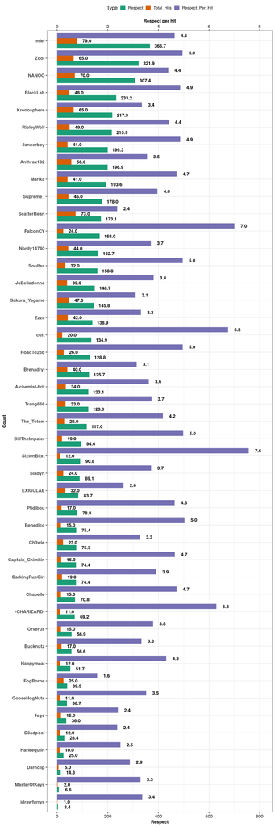

### War Score

Looking at war score gained and lost by each member.  
**The calculations IGNORE chain bonuses in order to better reflect actual contribution rather than landing a lucky hit**  
Total score earned: **3417.66**  
Total score lost: **5715.48**<sup>1</sup>  
Median net score per member: **-21.92**<sup>2</sup>

<sup>1</sup>Score lost will be 0 if using non-faction API key.  
<sup>2</sup>Using median instead of mean to avoid extreme values skewing the metric.

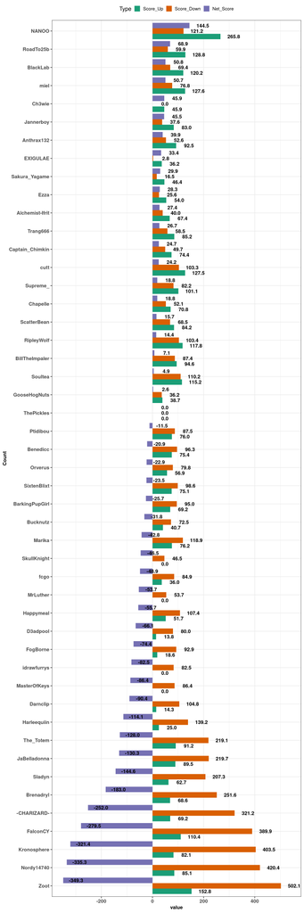

### Slackers

Members who did not meet 1% contribution cutoff

| Name | Contribution |
| --- | --- |
| Happymeal | 0.88 |
| SixtenBlixt | 0.88 |
| D3adpool | 0.88 |
| -CHARIZARD- | 0.80 |
| GooseHogNuts | 0.80 |
| Harleequiin | 0.73 |
| Darnclip | 0.37 |
| MasterOfKeys | 0.15 |
| idrawfurrys | 0.07 |
| MrLuther | 0.00 |
| ThePickles | 0.00 |
| SkullKnight | 0.00 |

### Energy

Summary of who wasted the most energy and who cost the enemy the most energy.  
Calculated by adding up Losses (and Stalemates, Defends, Escapes, Interrupts) and Defends, the multiplying the number by 25.  
E_Wasted means the member spent X energy on attacks that failed.  
E_Stolen means X energy was wasted by the enemy on attacking the member unsuccessfully.  
You might want to take a closer look at members with high E_Wasted values and remind them to pick fights they can win!

<sup>1</sup> These numbers will be 0 if you are using an API key WITHOUT faction access.

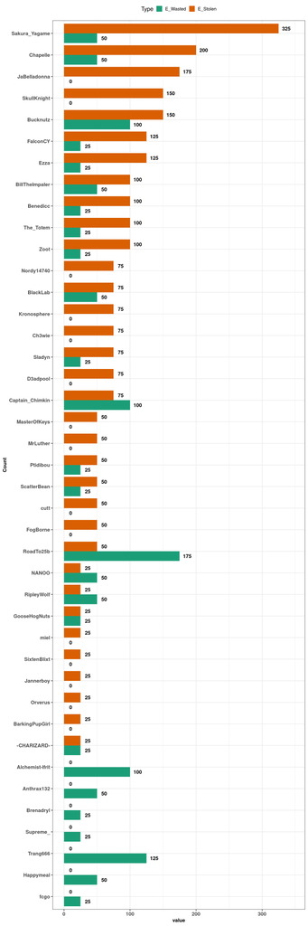

### Full table

Full table with filters and search

|  | Name | Total_Hits | Contribution | War_Hits | Non_War_Hits | Assists | Respect | Respect_Per_Hit | Respect_Lost | Score_Up | Score_Down | Net_Score |
| --- | --- | --- | --- | --- | --- | --- | --- | --- | --- | --- | --- | --- |
| 1 | fcgo | 15 | 1.1 | 15 | 0 | 0 | 35.99 | 2.4 | 21.26 | 35.99 | 84.87 | -48.88 |
| 2 | Ezza | 42 | 3.07 | 10 | 32 | 0 | 138.92 | 3.31 | 6.41 | 53.97000000000001 | 25.64 | 28.33 |
| 3 | Zoot | 65 | 4.75 | 16 | 49 | 2 | 321.8700000000001 | 4.95 | 130.55 | 152.8 | 502.1300000000002 | -349.33 |
| 4 | The_Totem | 28 | 2.05 | 15 | 13 | 0 | 117 | 4.18 | 62.32000000000001 | 91.17 | 219.14 | -127.97 |
| 5 | Happymeal | 12 | 0.88 | 12 | 0 | 0 | 51.72 | 4.31 | 26.87 | 51.72 | 107.42 | -55.7 |
| 6 | Marika | 41 | 2.99 | 12 | 29 | 1 | 193.61 | 4.72 | 30.5 | 76.16 | 118.95 | -42.79 |
| 7 | -CHARIZARD- | 11 | 0.8 | 11 | 0 | 0 | 69.22 | 6.29 | 83.68999999999998 | 69.22 | 321.2400000000001 | -252.02 |
| 8 | FalconCY | 24 | 1.75 | 13 | 11 | 0 | 168.03 | 7 | 98.56000000000002 | 110.39 | 389.9 | -279.51 |
| 9 | Trang666 | 33 | 2.41 | 20 | 13 | 0 | 123.01 | 3.73 | 14.64 | 85.15000000000002 | 58.45 | 26.7 |
| 10 | BarkingPupGirl | 19 | 1.39 | 15 | 4 | 0 | 74.36 | 3.91 | 28.79 | 69.25 | 94.99000000000001 | -25.74 |

[output cut: 38 more lines]

## Extra details

### Xanax and refill usage

Xanax and Energy refill usage during the war.

Total Xanax used: **383**  
Xanax costs: **316.09 M**  
Total Refills used: **105**  
Refill costs: **88.44 M**

Drug cost in plot is in millions.

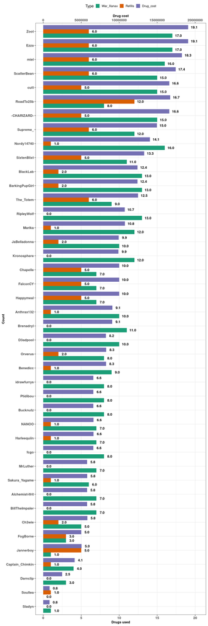

### Booster and can usage

Energy can and Booster usage during the war.

Total Boosters used: **60**  
Booster costs: **746.16 M**  
Total Cans used: **38**  
Can costs: **61.29 M**

All Boosters are assumed to be FHCs and Can price is set to average market value for ALL cans.

Booster cost in plot is in 10s of millions.

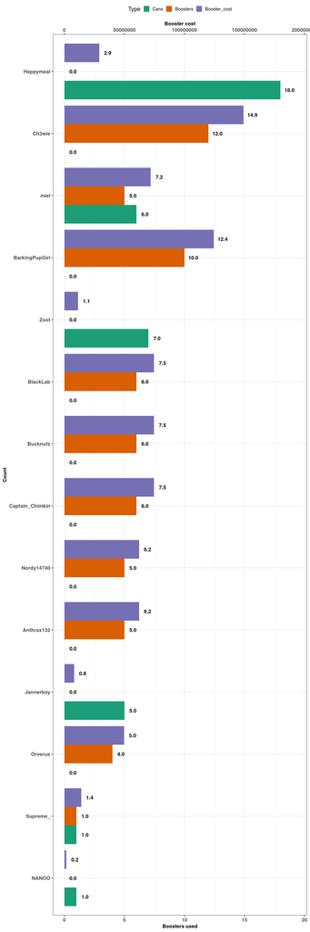

### Armory usage (BETA)

This is a summary of Armory usage during the preparation and war period.  
It can be useful for getting a good idea of how much consumables were used during the war in total.

<sup>1</sup> This section will be empty if you are using an API key WITHOUT faction access.

#### During preparation

```
## [1] "Preparation Armory usage:"
```

|  | Name | ID | action | amount | item | Hours_to_war |
| --- | --- | --- | --- | --- | --- | --- |
| 1 | Nordy14740 | 4033151 | used | 1 | Xanax | 71.34 |
| 2 | Supreme_ | 3153441 | used | 1 | Can of Damp Valley | 70.56 |
| 3 | Supreme_ | 3153441 | used | 1 | Blood Bag : O- | 70.56 |
| 4 | Supreme_ | 3153441 | used | 1 | Blood Bag : O- | 70.56 |
| 5 | Supreme_ | 3153441 | used | 1 | Blood Bag : O- | 70.56 |
| 6 | Supreme_ | 3153441 | used | 1 | Blood Bag : O- | 70.54 |
| 7 | Supreme_ | 3153441 | used | 1 | Small First Aid Kit | 70.54 |
| 8 | Supreme_ | 3153441 | used | 1 | Small First Aid Kit | 70.54 |
| 9 | Supreme_ | 3153441 | used | 1 | Blood Bag : O- | 70.54 |
| 10 | Supreme_ | 3153441 | used | 1 | Blood Bag : O- | 70.54 |

[output cut: 485 more lines]

```
## [1] "Preparation usage totals:"
```

|  | Action | Item | Count |
| --- | --- | --- | --- |
| 1 | used | Bottle of Beer | 236 |
| 2 | used | Xanax | 99 |
| 3 | used | Bag of Chocolate Kisses | 85 |
| 4 | loaned | Pepper Spray | 21 |
| 5 | used | Blood Bag : A+ | 15 |
| 6 | used | Blood Bag : O+ | 14 |
| 7 | used | First Aid Kit | 12 |
| 8 | used | Blood Bag : O- | 9 |
| 9 | used | Blood Bag : A- | 5 |
| 10 | used | Small First Aid Kit | 4 |

[output cut: 10 more lines]

```
## [1] "Only showing consumables"
```

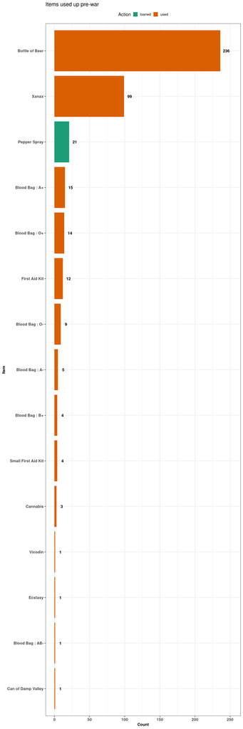

#### During war

```
## [1] "War Armory usage:"
```

|  | Name | ID | action | amount | item | Hours_to_end |
| --- | --- | --- | --- | --- | --- | --- |
| 1 | BarkingPupGirl | 2378660 | used | 1 | Blood Bag : O+ | 97.01 |
| 2 | BarkingPupGirl | 2378660 | used | 1 | Blood Bag : O+ | 97.01 |
| 3 | BarkingPupGirl | 2378660 | used | 1 | Blood Bag : O+ | 97 |
| 4 | BarkingPupGirl | 2378660 | used | 1 | Blood Bag : O+ | 97 |
| 5 | BarkingPupGirl | 2378660 | used | 1 | Blood Bag : O+ | 97 |
| 6 | Darnclip | 2892456 | used | 1 | Xanax | 96.96 |
| 7 | Nordy14740 | 4033151 | used | 1 | Small First Aid Kit | 96.88 |
| 8 | Brenadryl | 3551781 | used | 1 | Small First Aid Kit | 96.87 |
| 9 | Nordy14740 | 4033151 | used | 1 | Small First Aid Kit | 96.83 |
| 10 | Nordy14740 | 4033151 | used | 1 | First Aid Kit | 96.83 |

[output cut: 1239 more lines]

```
## [1] "War usage totals:"
```

|  | Action | Item | Count |
| --- | --- | --- | --- |
| 1 | used | Bottle of Beer | 356 |
| 2 | used | Bag of Chocolate Kisses | 208 |
| 3 | used | Small First Aid Kit | 108 |
| 4 | used | Blood Bag : A+ | 102 |
| 5 | used | Xanax | 89 |
| 6 | used | Blood Bag : O+ | 88 |
| 7 | used | First Aid Kit | 86 |
| 8 | used | Lollipop | 76 |
| 9 | used | Morphine | 63 |
| 10 | used | Blood Bag : O- | 29 |

[output cut: 17 more lines]

```
## [1] "Only showing consumables"
```

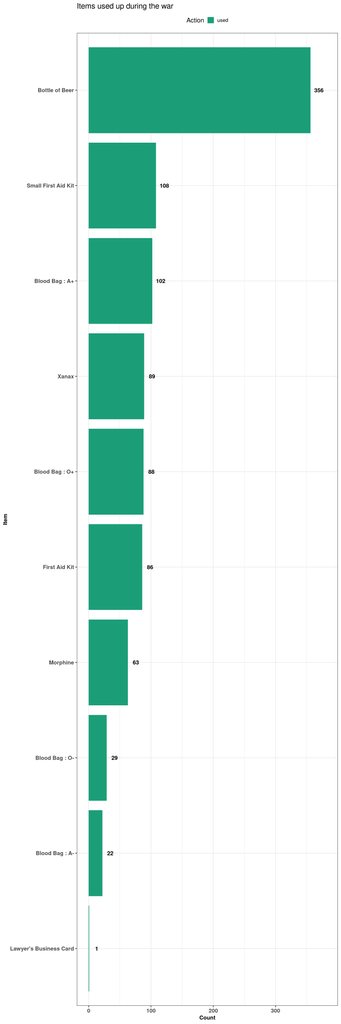

### Activity

Member activity during the war in hours.

```
## [1] "Correlation between activity and contribution:"
```

```
## [1] 0.62
```

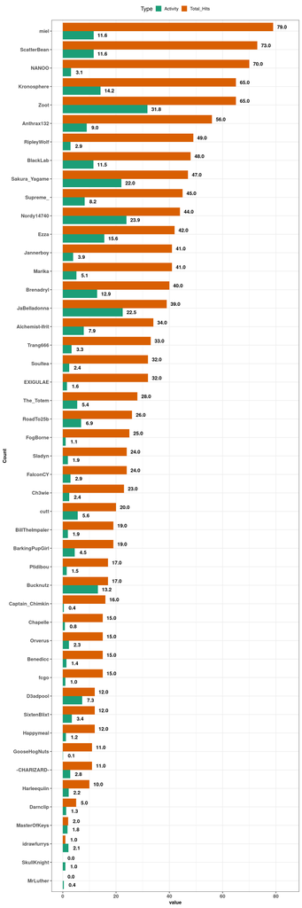

### Hospital

Summary of times hospitalized during the war

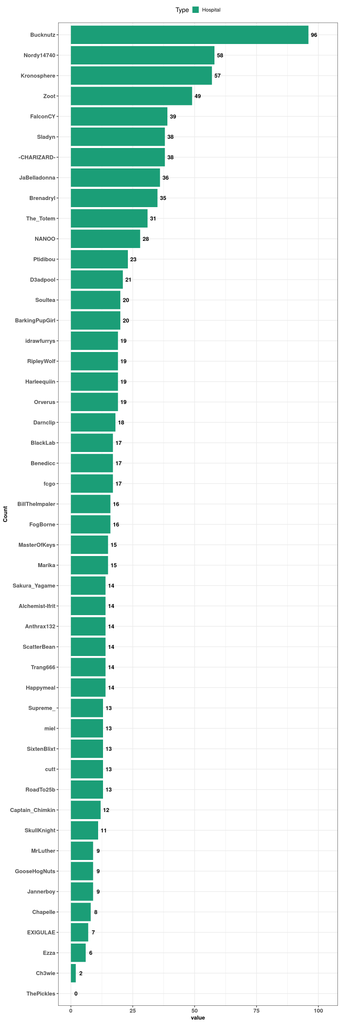

### Full table

|  | Name | War_Xanax | Refills | Boosters | Cans | Drug_cost | Booster_cost | Activity | Hospital |
| --- | --- | --- | --- | --- | --- | --- | --- | --- | --- |
| 1 | fcgo | 8 | 0 | 0 | 0 | 6602304 | 0 | 1.04 | 17 |
| 2 | Ezza | 17 | 6 | 0 | 0 | 19083546 | 0 | 15.57 | 6 |
| 3 | Zoot | 17 | 6 | 0 | 7 | 19083546 | 11290589.33 | 31.78 | 49 |
| 4 | The_Totem | 9 | 6 | 0 | 0 | 12481242 | 0 | 5.4 | 31 |
| 5 | Happymeal | 7 | 5 | 0 | 18 | 9988391 | 29032944 | 1.17 | 14 |
| 6 | Marika | 12 | 1 | 0 | 0 | 10745731 | 0 | 5.11 | 15 |
| 7 | -CHARIZARD- | 15 | 5 | 0 | 0 | 16590695 | 0 | 2.85 | 38 |
| 8 | FalconCY | 7 | 5 | 0 | 0 | 9988391 | 0 | 2.92 | 39 |
| 9 | Trang666 | 0 | 0 | 0 | 0 | 0 | 0 | 3.28 | 14 |
| 10 | BarkingPupGirl | 13 | 2 | 10 | 0 | 12413294 | 124360560 | 4.46 | 20 |

[output cut: 38 more lines]